# Computation Issues

Katherine Goode

September 29, 2020

This journal documents some of the computation issues I have run into and my “solutions” or “conclusions”.

```r
# Load libraries
library(caret)
library(lime)
library(plotly)
library(randomForest)
library(tidyverse)
```

# Plotly Dead Space Issue

I found an issue with plotly. Below is the reproducible example that I sent to Carson. He was able to fix the issue, so the example below no longer has the problem.

```r
# Example with Plotly to show dead space in heatmap

# System information
# R version 3.5.1 (2018-07-02)
# Platform: x86_64-apple-darwin15.6.0 (64-bit)
# Running under: macOS  10.14

# Load libraries
# library(plotly) # version 4.8.0
# library(ggplot2) # version 3.1.0
# library(tidyr) # version 0.8.2

# Example from: https://plot.ly/r/heatmaps/ -------------------------------------------

# Create dataset
m <- matrix(rnorm(9), nrow = 3, ncol = 3)

# Create plotly heatmap - no dead space to be found
plot_ly(x = c("a", "b", "c"), y = c("d", "e", "f"), z = m, type = "heatmap")

# Example using ggplotly function -----------------------------------------------------

# Reshape the data for ggplot
m_gathered <- data.frame(m) %>%
  gather(key = column) %>%
  mutate(row = factor(rep(c("X1", "X2", "X3"), 3))) %>%
  select(column, row, value)

# Create ggplot heatmap
p <- ggplot(m_gathered, aes(x = column, y = row, fill = value)) +
  geom_tile()

# Apply plotly to ggplot heatmap - dead space in the middle of (X1, X1)
ggplotly(p)

# Carson's suggested fix for now
style(ggplotly(p), hoverinfo = "skip", traces = 2)

# Create ggplot heatmap without a legend
p_nolegend <- ggplot(m_gathered, aes(x = column, y = row, fill = value)) +
  geom_tile() +
  theme(legend.position = "none")

# Apply plotly to ggplot heatmap - the dead space is gone!
ggplotly(p_nolegend)
```

# Caret vs RandomForest

The `lime` function in lime is set up to work with specific packages. For example, `lime` works with a random forest model fit using the caret package, but it is not set up to work with a random forest fit using the randomForest package. I found a suggestion to apply the function `as_classifier` from the lime package to a model fit using randomForest in order for the `lime` function to accept the model. It seemed to work. However, I wanted to compare the lime results from a model fit using caret and the same model fit using randomForest. To do this, I used the iris data. The code below goes through the process of fitting the two models (`rf_model` and `caret_model`). Then the `lime` and `explain` functions are applied to both models.

```r
# Code for comparing the output from LIME when the model is
# fit with caret and randomForest
# Last Updated: 2018/11/13

## Set up -----------------------------------------------------------------------------

# Split up the data set
iris_test <- iris[1:5, 1:4]
iris_train <- iris[-(1:5), 1:4]
iris_lab <- iris[[5]][-(1:5)]

## LIME with caret --------------------------------------------------------------------

# Create Random Forest model on iris data
caret_model <- train(iris_train, iris_lab, method = 'rf')

# Create an explainer object
caret_explainer <- lime::lime(iris_train, caret_model)

# Explain new observation
caret_explanation <- lime::explain(iris_test, caret_explainer, n_labels = 1, n_features = 4)

## LIME with randomForest -------------------------------------------------------------

rf_model <- randomForest(iris_train, iris_lab)

# Create an explainer object
rf_explainer <- lime::lime(iris_train, model = as_classifier(rf_model))

# Explain new observation
rf_explanation <- lime::explain(iris_test, rf_explainer, n_labels = 1, n_features = 4)
```

To compare the lime explanations from the two models, I extracted the $R^2$ value from the simple model, the simple model intercept, the simple model prediction, the feature values, and the feature weights from both explanation datasets. I computed the MSE between each of these values from the two models, and I plotted them on a scatterplot. Since lime is based on random permutations, I would not expect the values from the two models to be exact. However, I would like them to be close. The MSEs are all close to zero, and the plots suggest that the values do an okay job of following the 1-1 line. We decided this seems like the two versions of the explanations are reasonably exchangeable.

```r
## Comparisons -----------------------------------------------------------------------

# Grab the numeric caret explanation variables of interest
caret_numeric <- caret_explanation %>%
  select(model_r2, model_intercept, model_prediction, feature_value, feature_weight) %>%
  gather(key = "variable", value = "caret_value")

# Grab the numeric randomForest explanation variables of interest
rf_numeric <- rf_explanation %>%
  select(model_r2, model_intercept, model_prediction, feature_value, feature_weight) %>%
  gather(key = "variable", value = "rf_value")

# Join the two
lime_numeric <- caret_numeric %>%
  mutate(rf_value = rf_numeric$rf_value,
         variable = factor(variable))

# Look at the MSEs for the variables
lime_numeric %>%
  group_by(variable) %>%
  summarise(MSE = sum((caret_value - rf_value)^2) / dim(lime_numeric)[1])
```

```
## # A tibble: 5 x 2
##   variable                MSE
##   <fct>                 <dbl>
## 1 feature_value    0
## 2 feature_weight   0.0000178
## 3 model_intercept  0.00000992
## 4 model_prediction 0.00000943
## 5 model_r2         0.0000294
```

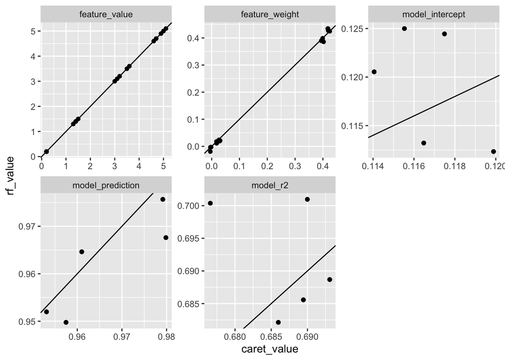

```r
# Scatterplots of the randomForest versus caret variable values
ggplot(lime_numeric, aes(x = caret_value, y = rf_value)) +
  geom_point() +
  facet_wrap( ~ variable, scales = "free") +
  geom_abline(intercept = 0, slope = 1)
```

# Comparing Furrr Times

```r
# It took about half the time when using the function from furrr!

library(furrr)
library(future)
library(tictoc)

# Slow way
plan(sequential)
tictoc::tic()
sensitivity_explain <- future_pmap(.l = as.list(sensitivity_inputs %>%
                                                         select(-case)),
                                          .f = run_lime, # run_lime is one of my helper functions
                                          train = hamby173and252_train %>% select(rf_features),
                                          test = hamby224_test %>% arrange(case) %>% select(rf_features) %>% na.omit(),
                                          rfmodel = as_classifier(rtrees),
                                          label = "TRUE",
                                          nfeatures = 3,
                                          seed = FALSE)
tictoc::toc()
# 218.188 sec elapsed

# Fast way
plan(multiprocess)
tictoc::tic()
sensitivity_explain <- future_pmap(.l = as.list(sensitivity_inputs %>%
                                                         select(-case)),
                                          .f = run_lime, # run_lime is one of my helper functions
                                          train = hamby173and252_train %>% select(rf_features),
                                          test = hamby224_test %>% arrange(case) %>% select(rf_features) %>% na.omit(),
                                          rfmodel = as_classifier(rtrees),
                                          label = "TRUE",
                                          nfeatures = 3,
                                          seed = FALSE)
tictoc::toc()
# 107.731 sec elapsed
```

# Understanding `seriation`

The example below is from the paper “Getting Things in Order: An Introduction to the R Package seriation” by Hahsler, Hornik, and Buchta.

```r
library(seriation)

data("iris")
x <- as.matrix(iris[-5])
x <- x[sample(seq_len(nrow(x))), ]
d <- dist(x)
o <- seriate(d)
str(o)
```

```
## List of 1
##  $ : 'ser_permutation_vector' int [1:150] 138 52 37 97 60 128 80 25 19 30 ...
##   ..- attr(*, "method")= chr "Spectral"
##  - attr(*, "class")= chr [1:2] "ser_permutation" "list"
```

```r
class(0)
```

```
## [1] "numeric"
```

```r
head(get_order(o), 15)
```

```
##  [1] 138  52  37  97  60 128  80  25  19  30  87 116  40 117  20
```

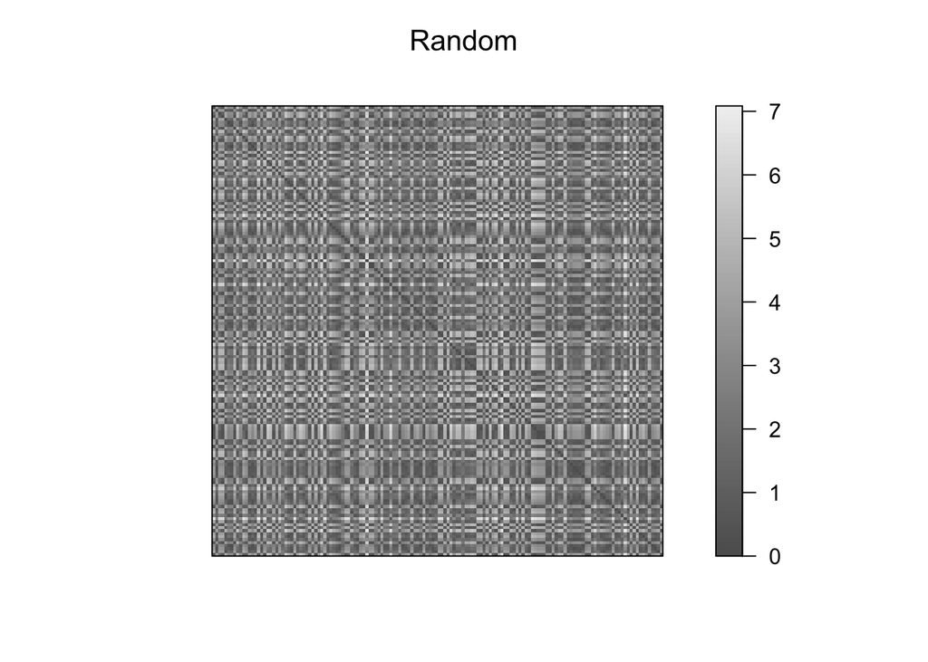

```r
pimage(d, main = "Random")
```

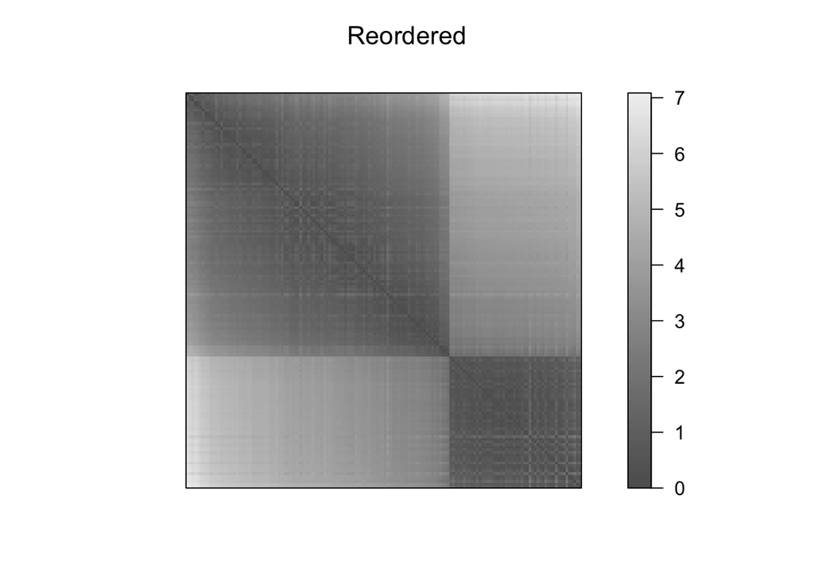

```r
pimage(d, o, main = "Reordered")
```

```r
cbind(random = criterion(d), reordered = criterion(d, o))
```

```
##                          random    reordered
## 2SUM               3.049907e+07 1.782159e+07
## AR_deviations      9.676554e+05 9.887392e+03
## AR_events          5.603890e+05 5.492400e+04
## BAR                1.660980e+05 5.660997e+04
## Cor_R              7.763929e-03 3.719539e-01
## Gradient_raw      -1.878200e+04 9.920580e+05
## Gradient_weighted -3.521581e+04 1.771427e+06
## Inertia            2.116761e+08 3.569103e+08
## Lazy_path_length   3.081463e+04 6.705889e+03
## Least_squares      7.889743e+07 7.648857e+07
## LS                 5.691793e+06 4.487365e+06
## ME                 5.823005e+03 7.253697e+03
## Moore_stress       1.197436e+04 1.111651e+03
## Neumann_stress     6.177089e+03 5.387757e+02
## Path_length        3.944366e+02 9.128657e+01
## RGAR               5.082432e-01 4.981317e-02
```

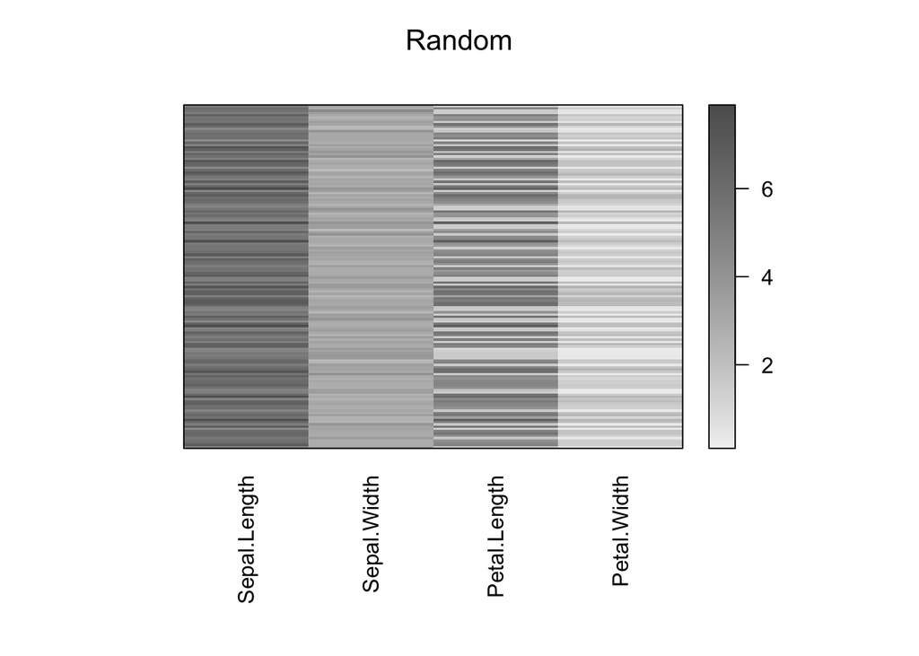

```r
pimage(x, main = "Random")
```

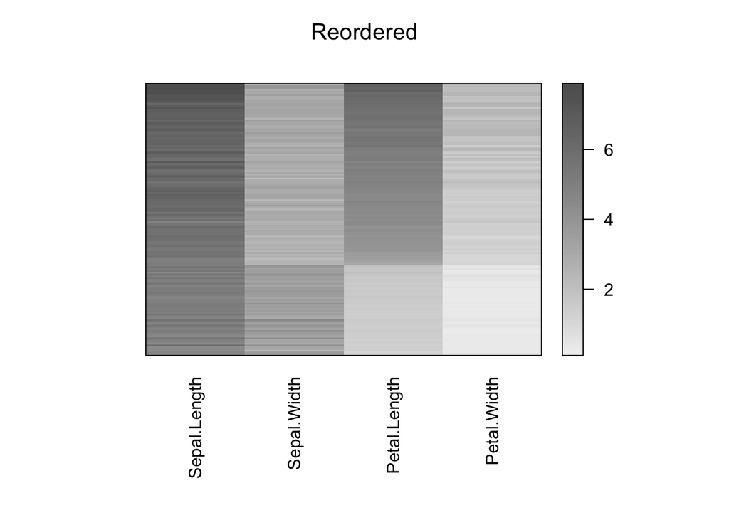

```r
o_2mode <- c(o, ser_permutation(seq_len(ncol(x))))
pimage(x, o_2mode, main = "Reordered")
```

I wanted to learn how to use the order that is output from `seriate` to create my own plot using `ggplot`. I create a new dataframe below that includes the order and create two plots. Note that the “order” from `seriate`, which can be obtained using `get_order` is a vector with the case numbers ordered (not the order associated with a case).

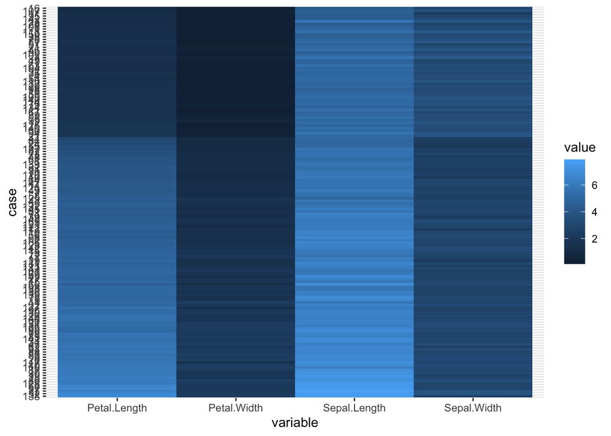

```r
# Add a case variable (ordered by seriate order) and my own order variable to my dataframe
x2 <- data.frame(x) %>%
  mutate(case = factor(1:n(), levels = get_order(o))) %>%
  arrange(case) %>%
  mutate(order = 1:n())

# Plot ordered using the case variable
x2 %>%
  gather(key = variable, value = value, 1:4) %>%
  ggplot(aes(x = variable, y = case, fill = value)) +
  geom_tile()
```

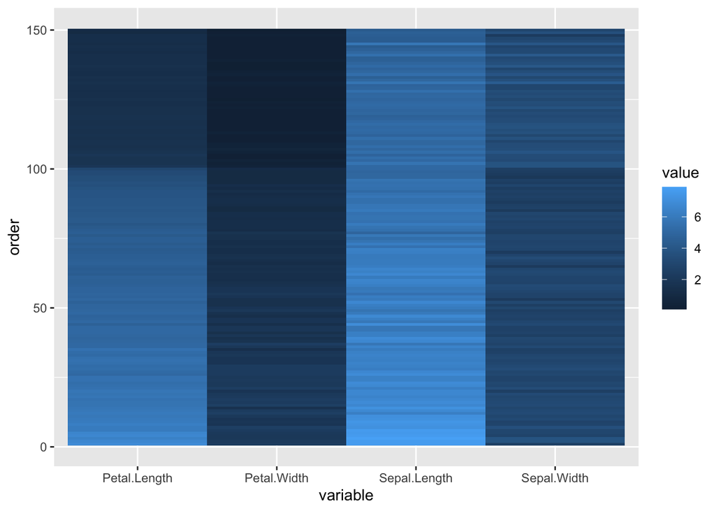

```r
# Plot ordered using the order variable
x2 %>%
  gather(key = variable, value = value, 1:4) %>%
  arrange(order) %>%
  ggplot(aes(x = variable, y = order, fill = value)) +
  geom_tile()
```